# Session 9: Structural Equation Modeling in International Business Research

Published course presentation · repository edition

Thierry Warin, PhD

HEC Montréal

## Outline · The hour ahead

1. Part I: SEM Basics
2. Example 1
3. Example 2
4. Example 3
5. Your Notebook: SEM Analysis Process

## What session 9 is for

### The mathematics

- Distinguish the **measurement** model from the **structural** model
- Read `=~` as “is measured by”, and write a model description
- Interpret a **standardised loading**, and say when an indicator is weak
- Report **CFI, TLI and RMSEA**, and say what each would have to be
- Decompose a **mediation** into direct and indirect paths

### The international business

- Measure a construct — trust, capability, institutional quality — you cannot observe
- State why good fit is not evidence that the model is correct
- Name the alternative model you rejected, and on what grounds

## Your Python so far

Everything you need to type is on one sheet — how to start Python in VS Codium on your platform, how to make a file and run it, the DataFrame basics, and every name from sessions 1 to 9, each with a line showing it in use.

> **[Python Cheatsheet · Session 09](https://warint.github.io/quantitative-methods/python-cheatsheet-09.pdf)** (PDF) · in the repository at `09-…/PYTHON-CHEATSHEET.pdf`

**One sheet per package, functions explained with pictures:** [pandas](https://warint.github.io/quantitative-methods/python-cheatsheets/pandas.pdf) · [NumPy](https://warint.github.io/quantitative-methods/python-cheatsheets/numpy.pdf) · [matplotlib](https://warint.github.io/quantitative-methods/python-cheatsheets/matplotlib.pdf) · [semopy](https://warint.github.io/quantitative-methods/python-cheatsheets/semopy.pdf) · [SciPy](https://warint.github.io/quantitative-methods/python-cheatsheets/scipy.pdf)

Print it, or keep it open beside the editor. Nothing on it is examinable; all of it is assumed.

## Part I: SEM Basics

## What is SEM?

- **Structural Equation Modeling (SEM)** is a comprehensive statistical framework used to test and estimate **causal relationships** based on both statistical data and theoretically grounded assumptions.
- It **integrates factor analysis and multiple regression**, allowing researchers to represent **latent variables** (unobserved theoretical constructs) through **observed indicators** (measured variables).
- SEM enables the specification of **complex interrelationships** among variables, including direct and indirect effects, within a single unified model.
- The central goal is to evaluate **how well the hypothesized model fits the empirical data**, typically by comparing the **model-implied covariance matrix** to the **observed covariance matrix** — the closer the correspondence, the better the model fit.

## Why use SEM?

- **Accounts for measurement error:** Unlike traditional regression, SEM explicitly models latent variables, thereby controlling for measurement error and yielding more reliable estimates of relationships between constructs.
- **Tests complex models:** SEM allows for the simultaneous estimation of multiple equations, handling several dependent variables, mediating relationships, and even feedback loops within a single coherent model.
- **Combines analyses:** Many common statistical methods are special cases of SEM—Confirmatory Factor Analysis (CFA) models the measurement structure alone, while path analysis focuses on observed variables. SEM unifies both, allowing for concurrent analysis of measurement and structural relationships.
- **Flexible modeling framework:** SEM accommodates diverse analytical extensions such as mediation, moderation, latent growth modeling, and multi-group comparisons, making it a versatile approach suitable for theory testing and model refinement across a wide range of disciplines.

## Key Terminology in SEM

- **Observed variable (indicator):** A directly measured variable, such as a survey item or test score, usually shown as a rectangle. Indicators provide the data used to estimate latent variables.
- **Latent variable (factor or construct):** An unobserved concept inferred from several observed indicators, typically shown as a circle or ellipse. Example: “Attitude” measured by multiple survey questions.
- **Exogenous and endogenous variables:** Exogenous variables function like independent variables (arrows go *out* from them); endogenous variables act like dependent variables (arrows point *into* them).
- **Path:** A one-headed arrow showing a directional (causal) relationship, similar to a regression coefficient. A two-headed arrow (↔︎) indicates a covariance or correlation between variables.
- **Error (disturbance):** The unexplained portion of a variable, represented by a small circle with an arrow pointing to the variable.

## Components of a SEM

An SEM has two main parts that work together:

- **Measurement model:** Connects **latent variables** (unobserved concepts) to their **observed indicators** (measured variables). Each latent factor is represented by several indicators, with arrows pointing from the latent variable (ellipse) to its indicators (rectangles). These arrows represent **factor loadings**, just like in a Confirmatory Factor Analysis (CFA).
- **Structural model:** Describes the **relationships among latent variables** (and sometimes observed ones). It functions like a set of regression equations linking the constructs. Arrows between latent variables show hypothesized influences, with coefficients interpreted like regression weights.

## Components of a SEM (cont.)

And then we talk about:

- **Covariances:** Exogenous (independent) variables are usually allowed to covary, represented by two-headed arrows (↔︎).
- **Path diagram:**
  - SEMs are often illustrated with diagrams—ellipses for latent variables,
  - rectangles for observed variables,
  - one-headed arrows for causal paths,
  - and two-headed arrows for covariances.

These diagrams make the model’s logic and structure easier to interpret.

## Components of a SEM (cont.)

## Example 1

## Example Dataset: HolzingerSwineford1939

Here are the **definitions and descriptions** of the variables in the **HolzingerSwineford1939** dataset, as used in most SEM and CFA examples (including in *lavaan*).

This dataset comes from **Holzinger & Swineford (1939)**, who studied the structure of mental abilities among schoolchildren.

The dataset includes **scores on nine ability tests**, grouped into three domains: **visual**, **textual (verbal)**, and **speed**.

## 🔹 **Dataset overview**

- **Sample:** 301 children (7th and 8th graders) from two schools — Pasteur and Grant-White.
- **Purpose:** To examine whether cognitive abilities can be explained by a small number of underlying (latent) factors.
- **Variables:** 9 observed test scores, 3 latent constructs.

## 🔹 **Latent and observed variables**

| **Latent variable (factor)** | **Observed indicators** | **Test name / meaning** | **Description** |
| --- | --- | --- | --- |
| **Visual ability** | **x1:** *VisualPerception* | *Visual perception test* | Measures perceptual speed and spatial reasoning using visual materials. |
|  | **x2:** *Cubes* | *Cubes test* | Assesses ability to visualize and manipulate 3D objects mentally. |
|  | **x3:** *Lozenges* | *Lozenges test* | Involves identifying geometric patterns, assessing spatial and shape recognition skills. |
| **Textual (verbal) ability** | **x4:** *ParagraphComprehension* | *Paragraph comprehension test* | Measures reading comprehension and understanding of written passages. |
|  | **x5:** *SentenceCompletion* | *Sentence completion test* | Tests vocabulary and verbal reasoning; complete sentences meaningfully. |
|  | **x6:** *WordMeaning* | *Word meaning test* | Assesses knowledge of word meanings and verbal intelligence. |
| **Speed (processing speed)** | **x7:** *Addition* | *Addition test* | Measures speed and accuracy in simple arithmetic. |
|  | **x8:** *CountingDots* | *Counting dots test* | Assesses visual scanning and quick counting accuracy. |
|  | **x9:** *Discrimination* | *Discrimination test* | Measures perceptual speed in identifying or distinguishing simple visual stimuli. |

## 🔹 **Latent and observed variables** (cont.)

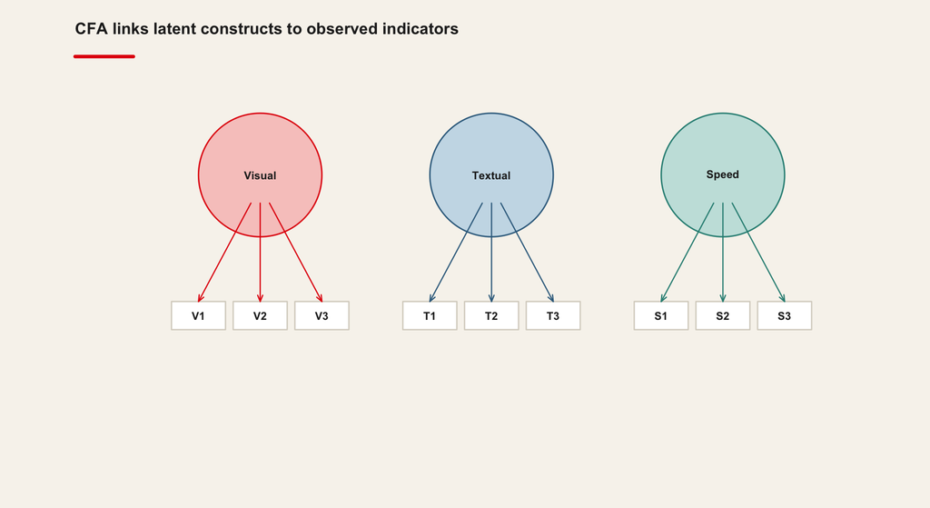

## 🔹 **Typical CFA model specification**

The confirmatory factor analysis model for these nine observed variables is typically written as:

```python
HS_model = """
  visual  =~ x1 + x2 + x3
  textual =~ x4 + x5 + x6
  speed   =~ x7 + x8 + x9
"""
```

This model proposes that:

- The **visual**, **textual**, and **speed** factors each explain the correlations among their respective tests.
- The factors may correlate with each other, representing related but distinct aspects of cognitive ability.

## 🔹 **Goal of the model**

The Holzinger–Swineford example demonstrates how SEM can:

- **Test the existence** of underlying mental ability factors.
- **Estimate factor loadings**, showing how strongly each test measures its latent ability.
- **Compare models** (e.g., one general intelligence factor vs. three correlated factors).

## 🔹 **Goal of the model** (cont.)

**In summary:**

- **x1–x3** = visual/spatial reasoning tasks
- **x4–x6** = verbal comprehension tasks
- **x7–x9** = processing speed tasks

## 🔹 **Goal of the model** (cont.)

## 🔹 **Goal of the model** (cont.)

```python
# In the VS Codium terminal, with .venv active:  python
import semopy
from semopy.examples import holzinger39

# 301 children, nine ability tests — ships with semopy, nothing to download
data = holzinger39.get_data()
data.head()
```

```
  id sex ageyr agemo  school grade       x1   x2    x3       x4   x5        x6
1  1   1    13     1 Pasteur     7 3.333333 7.75 0.375 2.333333 5.75 1.2857143
2  2   2    13     7 Pasteur     7 5.333333 5.25 2.125 1.666667 3.00 1.2857143
3  3   2    13     1 Pasteur     7 4.500000 5.25 1.875 1.000000 1.75 0.4285714
4  4   1    13     2 Pasteur     7 5.333333 7.75 3.000 2.666667 4.50 2.4285714
5  5   2    12     2 Pasteur     7 4.833333 4.75 0.875 2.666667 4.00 2.5714286
6  6   2    14     1 Pasteur     7 5.333333 5.00 2.250 1.000000 3.00 0.8571429
        x7   x8       x9
1 3.391304 5.75 6.361111
2 3.782609 6.25 7.916667
3 3.260870 3.90 4.416667
4 3.000000 5.30 4.861111
5 3.695652 6.30 5.916667
6 4.347826 6.65 7.500000
```

## **1. What the formula means**

Each line in your syntax, such as

```python
# "visual is measured by x1, x2 and x3"
# =~ reads as "is measured by": the latent variable on the left,
# its observed indicators on the right.
visual =~ x1 + x2 + x3
```

tells R that:

- **`visual`** is a **latent variable** (something not directly observed).
- It is **measured by** (or “indicated by”) the observed variables **x1, x2, and x3**.

In this example:

- `x1`, `x2`, and `x3` might be scores on visual perception tests.
- `visual` is the underlying construct that these tests reflect.

The operator `=~` literally means *“is measured by”*.

## **2. Behind-the-scenes defaults in lavaan**

When you write this concise syntax, **lavaan automatically handles** several technical steps that you’d otherwise need to specify manually:

1. **Fixing one loading to 1:** The first indicator’s factor loading (e.g., `x1` → `visual`) is fixed to 1.0 to set the scale of the latent variable. Without this, the latent variable would have an undefined scale.
2. **Adding residuals:** Each observed variable gets its own residual variance (measurement error term). These are estimated automatically.
3. **Correlating exogenous latents:** If you have more than one latent variable (e.g., `visual`, `textual`, `speed`), lavaan will, by default, allow them to **correlate** with each other — unless you specify otherwise.

This is why the model syntax is so compact but still complete.

## **3. Writing the model**

```python
# In the VS Codium terminal, with .venv active:
#   pip install semopy
import semopy
import numpy as np
import pandas as pd
```

This model defines three latent factors:

- **visual** — measured by x1–x3
- **textual** — measured by x4–x6
- **speed** — measured by x7–x9

All three are allowed to correlate by default.

## **4. Fitting the model**

```python
fit = semopy.Model(HS_model)
fit.fit(data)
```

## **5. Viewing results**

To see how well the model fits the data and inspect loadings use summary().

This command prints:

- **Factor loadings** (how strongly each indicator relates to its latent variable).
- **Residual variances** (unexplained variance per indicator).
- **Correlations** among latent variables.
- **Fit indices** such as χ², CFI, TLI, RMSEA, and SRMR.

## **5. Viewing results** (cont.)

- The code
- Model test
- Fit indices
- Loadings
- Covariances
- Variances

```python
# Parameter estimates, standardised alongside the raw ones
print(fit.inspect(std_est=True))

# Fit indices
print(semopy.calc_stats(fit).T)
```

[output not shown]

[output not shown]

[output not shown]

[output not shown]

[output not shown]

## Simple interpretation**

- If the factor loadings are **high (say > 0.7)** and **significant**, your indicators strongly represent the intended latent variable.
- If model fit indices (like **CFI > 0.95**, **RMSEA < 0.06**) look good, your measurement model aligns well with the observed data.
- Let’s go step by step and interpret these **Confirmatory Factor Analysis (CFA)** results in **plain language**.
- These come from the **HolzingerSwineford1939** dataset, specifically focusing on the **speed** factor and the relationships among the three latent variables (*visual*, *textual*, and *speed*).

## 1. **Factor loadings for “speed”**

| Indicator | Estimate | Std. Err | z-value | p-value | Interpretation |
| --- | --- | --- | --- | --- | --- |
| **x7** | 1.000 | — | — | — | This indicator (Addition test) is the reference item. Its loading is fixed to 1.0 to set the scale of the latent variable “speed.” |
| **x8** | 1.180 | 0.165 | 7.152 | < .001 | The loading is high and significant → “Counting Dots” test strongly measures the speed factor. |
| **x9** | 1.082 | 0.151 | 7.155 | < .001 | Also high and significant → “Discrimination” test strongly reflects the same speed ability. |

✅ **Interpretation:** All three indicators (x7, x8, x9) load significantly and positively on the *speed* latent variable. This means that children who perform well on one of these speed tasks tend to perform well on the others — evidence that these tasks measure a common underlying construct: **processing speed**.

## 2. **Covariances between latent variables**

| Covariance | Estimate | p-value | Interpretation |
| --- | --- | --- | --- |
| **visual ↔︎ textual** | 0.408 | < .001 | A strong positive relationship: students good at visual tasks also tend to be good at verbal/textual tasks. |
| **visual ↔︎ speed** | 0.262 | < .001 | A moderate positive relationship: faster students also tend to do better on visual reasoning tasks. |
| **textual ↔︎ speed** | 0.173 | < .001 | A weaker but still significant relationship: verbal ability and speed are related, though less strongly. |

✅ **Interpretation:** All three latent factors are **positively correlated**, meaning they represent **related but distinct cognitive abilities**. Visual, verbal, and speed skills overlap somewhat — but each factor captures its own dimension of ability.

## 3. **Variances**

[output not shown]

✅ **Interpretation:** The model captures meaningful variation in each ability domain. Residual variances are all significant (p < .001), showing that each test also has some unique measurement error — which is normal in psychological testing.

## **Plain summary**

- The **speed factor** is measured reliably by its three indicators (x7, x8, x9), all of which have strong, significant loadings.
- The **three latent abilities** — visual, textual, and speed — are **positively related**: children who perform well in one domain tend to perform well in others, though the correlations are not perfect (indicating distinct skills).
- The **model fits theoretical expectations** of the cognitive structure: three interrelated but separate mental ability factors.
- **Residuals and variances** suggest reasonable measurement precision and distinct variance among factors.

In simple terms:

> Students’ performance on speed-based tasks forms a coherent ability factor. This ability is moderately related to visual reasoning and, to a lesser extent, to verbal ability — supporting the idea that mental abilities are connected but not identical.

## Example 2

## Example Dataset: PoliticalDemocracy

The **PoliticalDemocracy** dataset is one of the classic examples used in structural equation modeling (SEM), originally featured in **Kenneth Bollen’s (1989)** foundational book *Structural Equations with Latent Variables*.

It’s included in the **lavaan** package, so you can access it right away in R without downloading anything.

## 🔹 **What the dataset contains**

This dataset is designed to illustrate how SEM handles **latent variables**, **measurement models**, and **structural relations** among them.

It includes **11 observed variables** related to industrialization and democracy for 75 countries.

There are **three latent constructs:**

1. **ind60** — Industrialization in 1960
2. **dem60** — Democracy in 1960
3. **dem65** — Democracy in 1965

## 🔹 **Observed variables (indicators)**

| **Latent Variable** | **Indicators (Observed Variables)** | **Description** |
| --- | --- | --- |
| **ind60** (Industrialization, 1960) | **x1:** GNP per capita (1960) **x2:** Energy consumption per capita (1960) **x3:** Percentage of labor force in industry (1960) | Captures a country’s level of industrialization around 1960 — higher values reflect greater economic development and industrial activity. |
| **dem60** (Democracy, 1960) | **y1:** Freedom of the press (1960) **y2:** Freedom of political opposition (1960) **y3:** Fairness of elections (1960) **y4:** Effectiveness of legislature (1960) | Reflects the degree of democratic rights and institutions at the start of the period. |
| **dem65** (Democracy, 1965) | **y5:** Freedom of the press (1965) **y6:** Freedom of political opposition (1965) **y7:** Fairness of elections (1965) **y8:** Effectiveness of legislature (1965) | Measures democracy five years later, allowing the model to capture changes in democratic performance over time. |

## 💡 **Notes:**

- Each set of indicators corresponds to a **latent construct** that is *not directly observable* (industrialization or democracy).
- The **dem65** variables repeat the same democracy indicators as **dem60**, but for a later year, allowing researchers to study how democracy evolves.
- The model tests both **measurement** (how well these indicators represent their latent constructs) and **structural** relations (e.g., does industrialization lead to more democracy over time?).

## Example lavaan specification:

```python
model = """
  # Measurement model
  ind60 =~ x1 + x2 + x3
  dem60 =~ y1 + y2 + y3 + y4
  dem65 =~ y5 + y6 + y7 + y8
  # Regressions — the structural part
  dem60 ~ ind60
  dem65 ~ ind60 + dem60
"""
```

This model is the canonical **PoliticalDemocracy SEM** — it shows how **industrialization in 1960** affects **democracy in 1960** and **1965**, while also accounting for stability and measurement consistency over time.

Each set of observed variables measures one latent construct.

## Example lavaan specification: (cont.)

[figure not shown]

## 🔹 **Structure of the SEM**

The model tests both **measurement** and **structural** relationships:

- The **measurement model** defines how the latent variables (*ind60*, *dem60*, *dem65*) are measured by their observed indicators.
  - *ind60* is measured by *x1, x2, x3*
  - *dem60* is measured by *y1, y2, y3, y4*
  - *dem65* is measured by *y5, y6, y7, y8*
- The **structural model** defines the causal paths among the latent variables:
  - *ind60 → dem60*
  - *dem60 → dem65*
  - *ind60 → dem65* (direct effect)

This structure allows for the examination of how industrialization affects democracy both directly and indirectly over time.

## 🔹 **Loading and exploring the dataset**

You can load and view it directly in R:

```python
from semopy.examples import political_democracy

# 75 countries: industrialisation and democratic institutions
PoliticalDemocracy = political_democracy.get_data()
PoliticalDemocracy.head()
```

```
     y1       y2       y3       y4       y5       y6       y7       y8       x1
1  2.50 0.000000 3.333333 0.000000 1.250000 0.000000 3.726360 3.333333 4.442651
2  1.25 0.000000 3.333333 0.000000 6.250000 1.100000 6.666666 0.736999 5.384495
3  7.50 8.800000 9.999998 9.199991 8.750000 8.094061 9.999998 8.211809 5.961005
4  8.90 8.800000 9.999998 9.199991 8.907948 8.127979 9.999998 4.615086 6.285998
5 10.00 3.333333 9.999998 6.666666 7.500000 3.333333 9.999998 6.666666 5.863631
6  7.50 3.333333 6.666666 6.666666 6.250000 1.100000 6.666666 0.368500 5.533389
        x2       x3
1 3.637586 2.557615
2 5.062595 3.568079
3 6.255750 5.224433
4 7.567863 6.267495
5 6.818924 4.573679
6 5.135798 3.892270
```

This will show the first few rows, typically looking like this:

[output not shown]

## 🔹 **Specifying the model in lavaan**

Here’s the model Bollen used, implemented in **lavaan**:

```python
model = """
  # measurement model
  ind60 =~ x1 + x2 + x3
  dem60 =~ y1 + y2 + y3 + y4
  dem65 =~ y5 + y6 + y7 + y8
  # regressions
  dem60 ~ ind60
  dem65 ~ ind60 + dem60
"""
```

Then fit it:

```python
fit = semopy.Model(model)
fit.fit(PoliticalDemocracy)
```

## 🔹 **Viewing the results**

- The code
- Model test
- Fit indices
- Loadings
- Regressions and covariances
- Variances

```python
print(fit.inspect(std_est=True))
print(semopy.calc_stats(fit).T)
```

[output not shown]

[output not shown]

[output not shown]

[output not shown]

[output not shown]

### 🔹 **Interpretation**

## 1. **Overall model fit**

This tells you that your hypothesized model (relationships among *ind60*, *dem60*, and *dem65*) is plausible and consistent with the data.

## 2. **Measurement model (factor loadings)**

Each latent variable is measured by several indicators. The loadings show **how strongly each observed variable reflects its latent construct.**

## **ind60 (industrialization in 1960)**

[output not shown]

✅ All are high (close to 1.0), so the indicators are **excellent measures of industrialization**.

## **dem60 (democracy in 1960)**

[output not shown]

✅ All significant; the latent factor is **well represented** by these four democracy indicators.

## **dem65 (democracy in 1965)**

[output not shown]

✅ Similarly, all loadings are high and significant → **the construct of democracy in 1965 is measured well**.

## 3. **Structural model (paths among latent variables)**

| Path | Standardized coefficient | p-value | Meaning |
| --- | --- | --- | --- |
| **ind60 → dem60** | 0.45 | < .001 | Industrialization in 1960 **significantly increases democracy** in 1960. |
| **ind60 → dem65** | 0.18 | 0.01 | Industrialization in 1960 has a **smaller but still positive effect** on democracy in 1965. |
| **dem60 → dem65** | 0.89 | < .001 | Democracy is **very stable** over time — democracy in 1960 is the main driver of democracy in 1965. |

✅ Interpretation:

- The path from *ind60 → dem60* supports the idea that economic development promotes democratic institutions.
- The very strong *dem60 → dem65* path means that **once democracy exists, it tends to persist**.
- The direct *ind60 → dem65* path, while smaller, shows **industrialization also helps maintain democracy over time**, beyond its indirect effect through *dem60*.

## 4. **Covariances and residuals**

All other residual variances (errors) are reasonable, meaning that **most of the variance** in each observed variable is explained by its latent factor.

## 5. **R² interpretation**

[output not shown]

## 6. **Plain summary**

  > *Economic development promotes democracy, which once established tends to endure.*

## Example 3

## Example Path Diagram

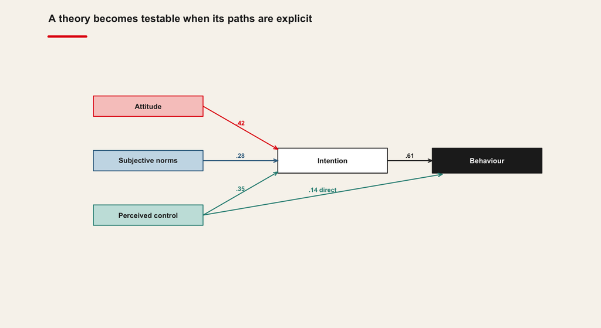

## Example Path Diagram (cont.)

In this model, **Intention** is the **endogenous latent variable** (dependent variable), while **Attitudes**, **Subjective Norms**, and **Perceived Control** are **exogenous latent predictors**. All exogenous constructs are typically allowed to covary freely.

## Example: Latent Constructs and Indicators (TPB)

In the **Theory of Planned Behavior (TPB)** example, each **latent construct** is measured by several **survey items**:

- **Attitudes (latent factor):** measured by two semantic differential items assessing evaluations of teen sexual activity (e.g., *“Having sex as a teen is foolish vs. wise”*, *“…harmful vs. beneficial”*).
- **Subjective Norms (latent factor):** measured by two items on perceived social approval (e.g., *“How much does your boyfriend/girlfriend approve?”*, *“How much does a close friend approve?”*).
- **Perceived Control (latent factor):** measured by two items on self-efficacy (e.g., *“How much self-control do you have to not have sex?”*, *“Do you know how to refuse sex?”*).
- **Intention (latent factor):** measured by two items on planned behavior (e.g., *“I intend not to have sex in the next year”*, *“I intend to avoid situations that might lead to sex.”*).

All items were rated on a **7-point scale** (e.g., from *“Foolish”* to *“Wise”*), yielding continuous data for SEM analysis. Although this example uses **two indicators per construct** for simplicity, it is generally recommended to have **at least three indicators** per latent variable to ensure **model identification and reliability**.

## Example: Latent Constructs and Indicators (TPB) (cont.)

| Latent Variable | Indicators (Observed Variables) | Example meaning |
| --- | --- | --- |
| **Intention** | `int.abs`, `int.avoid` | “I intend to abstain from sex” / “I intend to avoid situations that might lead to sex” |
| **Attitudes** | `sex.fool`, `sex.harm` | “Having sex as a teen is foolish vs. wise” / “Having sex as a teen is harmful vs. beneficial” |
| **Subjective Norms** | `love.sex`, `frnd.sex` | Perceived approval from partner and friend |
| **Perceived Control** | `self.cntl`, `how.ref` | “How much self-control do you have to not have sex?” / “Do you know how to refuse sex?” |

## SEM Dataset Simulation

```python
rng = np.random.default_rng(123)
n = 400

# Latent variables
Attitude = rng.normal(size=n)
Norms    = rng.normal(size=n)
Control  = rng.normal(size=n)
Intention = 0.4 * Attitude + 0.3 * Norms + 0.2 * Control + rng.normal(0, 0.5, n)
```

## Latent variables (cont.)

```python
import semopy
import numpy as np
import pandas as pd
from scipy import stats
```

## Latent variables (cont.)

```python
# The R deck reads a local tpb.csv. We simulate the same structure so the
# slide runs anywhere, with no file to find.
tpb = pd.DataFrame({
    "sex_fool": Attitude + rng.normal(0, .5, n),
    "sex_harm": Attitude + rng.normal(0, .5, n),
    "frnd_sex": Norms    + rng.normal(0, .5, n),
    "love_sex": Norms    + rng.normal(0, .5, n),
    "sex_ctrl": Control  + rng.normal(0, .5, n),
    "sex_plan": Control  + rng.normal(0, .5, n),
    "intend_a": Intention + rng.normal(0, .5, n),
    "intend_b": Intention + rng.normal(0, .5, n),
})
tpb.head()
```

[output not shown]

## Assessing assumptions

```python
# Univariate normality, one test per indicator
for col in tpb.columns:
    W, p = stats.shapiro(tpb[col])
    print(f"{col:10s} W = {W:.4f}   p = {p:.4f}")
```

[output not shown]

## Assessing assumptions

```python
# Multivariate normality: Mardia's skewness and kurtosis
X = tpb.to_numpy()
Xc = X - X.mean(0)
S_inv = np.linalg.inv(np.cov(X, rowvar=False))
D = Xc @ S_inv @ Xc.T
n_, k = X.shape
b1 = (D ** 3).sum() / n_ ** 2      # every pair i, j — joint skewness
b2 = (np.diag(D) ** 2).sum() / n_  # the diagonal only: squared distances
# Under multivariate normality b2 has mean k(k+2); trace(D @ D) would sum the
# whole matrix and land orders of magnitude away from it.
print(f"Mardia skewness {b1:.3f}   kurtosis {b2:.2f}  (expected {k*(k+2)})")
```

[output not shown]

## Model speicification

```python
# Measurement model + structural model, in one description
model = """
  attitudes =~ sex_fool + sex_harm
  norms     =~ frnd_sex + love_sex
  control   =~ sex_ctrl + sex_plan
  intention =~ intend_a + intend_b
  intention ~ attitudes + norms + control
"""

fit_mod = semopy.Model(model)
fit_mod.fit(tpb)
```

## Model fit

```python
stats_tbl = semopy.calc_stats(fit_mod)
print(stats_tbl[["chi2", "DoF", "chi2 p-value"]].T)
```

[output not shown]

```python
print(stats_tbl[["RMSEA"]].T)
```

[output not shown]

```python
print(stats_tbl[["CFI", "TLI", "GFI"]].T)
```

[output not shown]

## Measurement Model Results

```python
# Standardised loadings — the measurement part
ins = fit_mod.inspect(std_est=True)
print(ins[ins["op"] == "~"][["lval", "rval", "Estimate", "Est. Std", "p-value"]])
```

[output not shown]

```python
# R-squared for each indicator
print(fit_mod.inspect(std_est=True).query("op == '~~' and lval == rval"))
```

[output not shown]

## Structural Model Results

```python
# The structural paths: what predicts intention
print(ins[(ins["op"] == "~") & (ins["rval"].isin(["attitudes", "norms", "control"]))])
```

[output not shown]

## Graph

[figure not shown]

## Measurement Model (Latent Variable Model)

The **measurement model** defines how **latent variables** are represented by their **observed indicators**. It corresponds to the **Confirmatory Factor Analysis (CFA)** part of an SEM.

- Each **indicator** loads on a specific **latent factor**. For instance, if *Attitudes* is latent, its related survey items should all load significantly on that factor.
- Indicators of the same latent factor are assumed to correlate **only through that factor**. Direct correlations between indicators of different factors are not included unless theoretically justified as **error covariances**.
- The main results from the measurement model are **factor loadings** (showing how strongly each item reflects its latent construct) and **indicator reliability**. Loadings above roughly **0.7** are considered strong.
- Testing the measurement model ensures that each group of indicators truly measures the intended construct. While CFA can be run separately, in SEM it is estimated together with the structural model.

## Structural Model (Relationships Among Constructs)

The **structural model** describes the **causal relationships** among variables—usually **latent constructs**—that form the theoretical core of the SEM.

- It functions like a **system of regression equations**, where one variable is explained by others according to the theory being tested. For example, in the TPB framework:

  $$\text{Intention} = \beta_1 \text{Attitudes} + \beta_2 \text{Norms} + \beta_3 \text{Control} + \zeta$$

## Advantages over Separate Analyses

- **Model tested as a whole:** SEM simultaneously estimates both the **measurement** and **structural** components, allowing researchers to evaluate the **overall model fit**—a feature unavailable in standard regression or isolated analyses.
- **Controls for measurement error:** Unlike traditional regression, which assumes perfect measurement, SEM explicitly models **measurement error** through latent variables. This leads to **less biased and more accurate** estimates of relationships among constructs.
- **Theory-driven confirmation:** SEM is primarily a **confirmatory** approach. Researchers specify a model grounded in theory and then test whether the data support it. This contrasts with **exploratory methods** such as factor analysis or stepwise regression, which are data-driven. SEM thus promotes clear theoretical reasoning before empirical testing.

## Your Notebook: SEM Analysis Process

## Steps in Conducting an SEM Analysis

A typical SEM study follows a **structured sequence** of steps:

- **Model Specification:** Define the theoretical model and represent it with a **path diagram**. Clearly indicate which indicators load on which latent factors (measurement model) and which variables influence others (structural model). This step translates theoretical assumptions into formal equations.
- **Data Preparation:** Identify the **measurement level** of each observed variable (continuous, ordinal, etc.) and verify that coding is correct (e.g., properly handling reverse-coded items). Check data quality and consider normalization or transformation when needed.

## Steps in Conducting an SEM Analysis

- **Assess Assumptions:** Examine the data for **multivariate normality**, **outliers**, and **missing values**. SEM methods like Maximum Likelihood (ML) assume multivariate normality; if this is violated, use **robust ML** or **weighted least squares**. Also, ensure a sufficient sample size—typically **N > 200** for stable estimation.
- **Model Estimation:** Select an **estimation method** suited to the data type (e.g., ML for continuous data, WLSMV for ordinal data). Fit the model and obtain parameter estimates, including loadings, path coefficients, and variances.

## Steps in Conducting an SEM Analysis

- **Model Fit Evaluation:** Assess how well the model reproduces the observed data using multiple **fit indices**—such as Chi-square, RMSEA, CFI, TLI, and SRMR. If model fit is poor, explore **theory-based modifications** or compare alternative specifications.
- **Interpret Results:** If fit is acceptable, interpret key parameters:
  - **Factor loadings** – how well each item represents its latent construct.
  - **Regression coefficients** – strength and direction of structural paths.
  - **( R^2 )** – variance explained in each endogenous variable. Discuss the theoretical meaning and significance of these findings.

## Steps in Conducting an SEM Analysis

- **Report and Refine:** Present a **final path diagram** with standardized coefficients and fit indices. If needed, refine or compare models (using **AIC**, **BIC**, or Chi-square difference tests**). Interpret results within the theoretical framework, noting any limitations or assumptions.

*(Remember: SEM is primarily **confirmatory**, not exploratory. A strong theoretical foundation should guide the model before statistical testing.)*

## Assumptions in SEM

- **Multivariate Normality:** Classical SEM using **Maximum Likelihood (ML)** assumes that the observed variables follow a **multivariate normal distribution**.
  - Check **univariate normality** (e.g., Shapiro–Wilk test) and **multivariate normality** (e.g., Mardia’s test).
  - If data are non-normal, use **robust estimation methods** such as the **Satorra–Bentler correction** or **robust ML (MLR)**.
  - For ordinal or highly skewed data, use estimators less sensitive to normality (e.g., **WLSMV**).
- **Linearity:** Relationships among variables are assumed to be **linear**, unless nonlinearity is explicitly modeled. Examine scatterplots or residuals to verify that linearity is a reasonable approximation.
- **Adequate Sample Size:** SEM involves many parameters and thus requires **large samples** for stable estimation.
  - Rule of thumb: about **5–10 observations per parameter**, with a minimum of **N ≈ 200** recommended.
  - Small samples can cause **non-convergence** or **unstable estimates**.
- **No Perfect Multicollinearity:** Variables (indicators or latent constructs) should not be **perfectly or nearly perfectly correlated**. High collinearity makes it difficult to estimate separate effects and can distort parameter estimates.
- **Correct Model Specification:** The model should accurately represent the theoretical relationships—no omitted variables, incorrect paths, or reversed causality. A misspecified model may yield **poor fit** or **biased estimates** even if computed successfully.

If assumptions are violated, remedies include **robust ML**, **bootstrapping standard errors**, or using alternative estimators. Modern SEM software, such as **lavaan** in R, provides several of these robust options.

## Q&A / Discussion

Feel free to ask questions or request clarification on:

- **Model fit indices:** How to interpret χ², RMSEA, CFI, TLI, SRMR, or compare competing models.
- **Model implementation:** Tips for specifying, estimating, and troubleshooting models in **lavaan**.
- **Mediation and moderation:** Understanding indirect effects and how to test them robustly.
- **Multi-group SEM:** Assessing measurement invariance and comparing models across groups or cultures.
- **Assumptions and alternatives:** When to use SEM versus regression, path analysis, or PLS approaches.

*(This concludes the presentation. Thank you for your attention and engagement!)*

## Before the next session

**Required:** the next session’s article, its Dataverse package, and the self-check. That is the pre-session deck.

**Optional:** the **QMIB Lab** for this session — a knowledge check on the hour you have just sat through: **[warin.ca/qmib-labs](https://warin.ca/qmib-labs/qmib-lab-09.html)**

Never a prerequisite, never marked for correctness. A completed report counts toward participation because attempting it is the engagement being measured.